# Assignment 3

Emma Colley

9/30/2020

```r
library(sf)
library(tidyverse)
library(ggthemes)
library(ggspatial)
library(units)
library(nngeo)
library(ggplot2)
library(viridis)
```

# Introduction

This week, I’ve examined five datasets from the Boston Open Data portal. I selected Boston because I want to learn more about the Boston neighborhoods we’re analyzing in Studio. I was originally hoping to map Rochester, NY but the geospatial data was only available on DVD by mail. So old fashion! The datasets I’m representing are:

*A) Free public WiFi access points*

*B) Community centers*

*C) Open space*

*D) Neighborhoods of Boston*

*E) Public schools*

I learned how to hide my code by looking at my classmate Alex Cox’s HTML. I also failed to load crucial libraries during my first attempt at these figures, which I also learned by referencing Alex. I tried to experiment with colors and themes as much as time allowed, but I’m only just beginning.

## Mapping All of the Data

```r
nbhoods <- st_read("http://bostonopendata-boston.opendata.arcgis.com/datasets/3525b0ee6e6b427f9aab5d0a1d0a1a28_0.kml?outSR=%7B%22latestWkid%22%3A2249%2C%22wkid%22%3A102686%7D", quiet = TRUE)

openspace <- st_read("http://bostonopendata-boston.opendata.arcgis.com/datasets/2868d370c55d4d458d4ae2224ef8cddd_7.kml", quiet = TRUE)

commcenter <- st_read("http://bostonopendata-boston.opendata.arcgis.com/datasets/acedd06b39854088b0f2fefccffebf84_0.kml?outSR=%7B%22latestWkid%22%3A3857%2C%22wkid%22%3A102100%7D", quiet = TRUE)

wifi <- st_read("http://bostonopendata-boston.opendata.arcgis.com/datasets/4b803745fedd4e88861967d16a1e07fb_0.kml?outSR=%7B%22latestWkid%22%3A3857%2C%22wkid%22%3A102100%7D", quiet = TRUE)

school <- st_read("http://bostonopendata-boston.opendata.arcgis.com/datasets/1d9509a8b2fd485d9ad471ba2fdb1f90_0.kml?outSR=%7B%22latestWkid%22%3A2249%2C%22wkid%22%3A102686%7D", quiet = TRUE)
```

```r
MA_state_plane <- "+proj=lcc +lat_1=41.71666666666667 +lat_2=42.68333333333333 +lat_0=41 +lon_0=-71.5 +x_0=200000 +y_0=750000 +ellps=GRS80 +units=m +no_defs"

nbhoods <- nbhoods %>%
  st_transform(MA_state_plane)

openspace <- openspace %>%
  st_transform(MA_state_plane)

commcenter <- commcenter %>%
  st_transform(MA_state_plane)

wifi <- wifi %>%
  st_transform(MA_state_plane)

school <- school %>%
  st_transform(MA_state_plane)
```

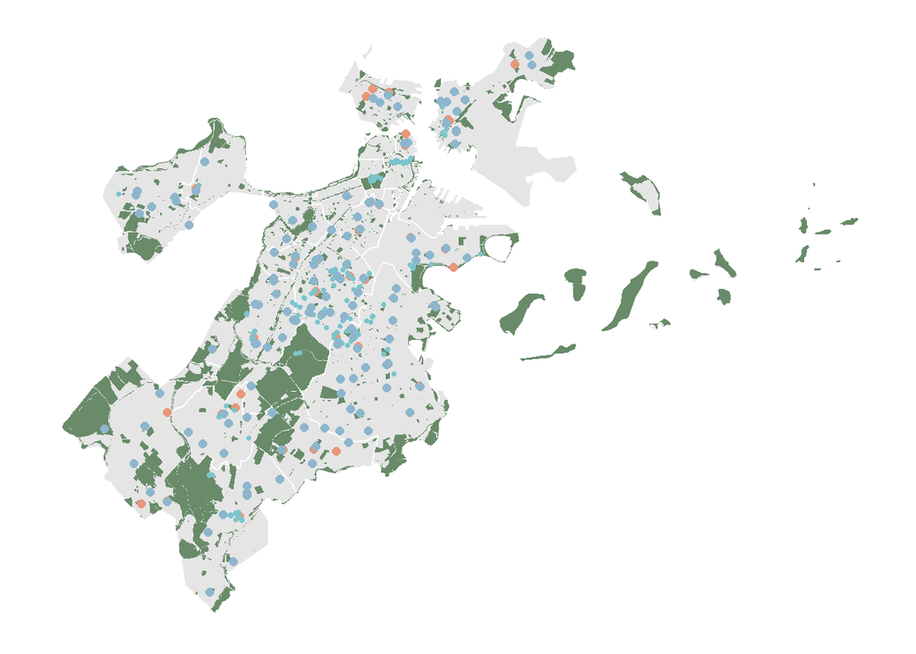

```r
ggplot(nbhoods) +
  geom_sf(fill = "grey90", color = "white") +
  geom_sf(data = openspace, fill = "darkseagreen4", color = NA) +
  geom_sf(data = commcenter, color = "darksalmon", size = 2) +
  geom_sf(data= wifi, color = "cadetblue3", size = 1) +
  geom_sf(data= school, color = "lightskyblue3", size = 2) +
  theme_map()
```

## 1) The number and proportion of A points within a specified distance of B points.

How many of the “Wicked Free Wifi” spots (A) are within 30 meters of a community center (B)?

```r
commcenter_buffer <- st_buffer(commcenter, dist = 30) %>%
  st_union()
```

```r
wifi_commcenter <- wifi[commcenter_buffer,]
```

```r
wifi <- wifi %>%
  st_join(wifi_commcenter) %>%
  mutate(by_commcenter = !is.na(Name.y))
```

```r
n_commcenter_wifi <- sum(wifi$by_commcenter)

n_commcenter_wifi
```

```
## [1] 9
```

```r
n_wifi <- length(wifi$by_commcenter)

pct_commcenter_wifi <- n_commcenter_wifi / n_wifi

pct_commcenter_wifi
```

```
## [1] 0.0505618
```

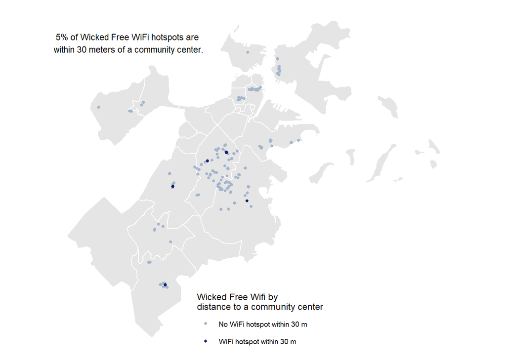

```r
left_side  <- st_bbox(wifi)$xmin
top_side <- st_bbox(wifi)$ymax

ggplot(nbhoods) +
  geom_sf(fill = "gray90", color = "white") +
  geom_sf(data = wifi, size = 1,
          aes(color = by_commcenter)) +
  scale_color_manual(values = c("lightsteelblue3", "midnightblue"),
          name = "Wicked Free Wifi by\ndistance to a community center",
          labels = c("No WiFi hotspot within 30 m",
                     "WiFi hotspot within 30 m")) +
  annotate(geom = "text", x = left_side,
           y = top_side,
           label = paste(prettyNum(100*pct_commcenter_wifi, digits = 0),
                         "% of Wicked Free WiFi hotspots are\nwithin 30 meters of a community center.",
                         sep = ""),
           hjust = .3, vjust = 0, size = 3) +
  theme_map() +
  theme(legend.position = c(.35, 0)) +
  theme(legend.background = element_rect(fill = alpha("white", 0.4)))
```

## 2) The number and proportion of A points within C polygons.

How many of the “Wicked Free Wifi” hotspots (A) are within each open space in Boston (C)?

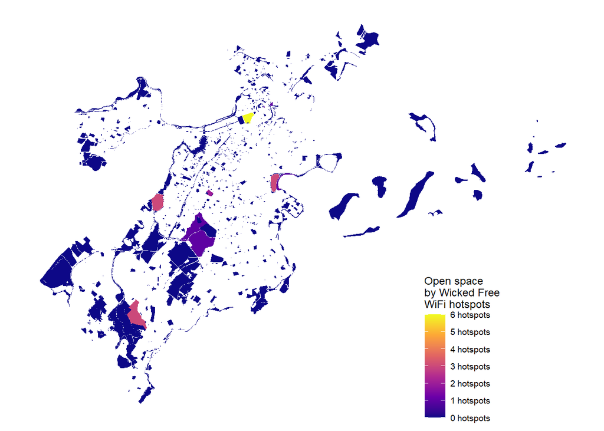

```r
openspace <- openspace %>%
  mutate(num_wifi = lengths(st_covers(openspace, wifi)))

ggplot(openspace) +
  geom_sf(color = NA,
          aes(fill = num_wifi)) +
  scale_fill_viridis_c(option = "C", name = "Open space\nby Wicked Free\nWiFi hotspots", breaks = breaks <- seq(0, 6, by = 1),
                       labels = paste(prettyNum(breaks), "hotspots")) +
theme_map() +
  theme(legend.position = c(.7, 0)) +
  theme(legend.background = element_rect(fill = alpha("white", 0.5)))
```

## 3) The number and proportion of A points within D polygons.

How many of the “Wicked Free Wifi” hotspots (A) are within each Boston neighborhood (D)?

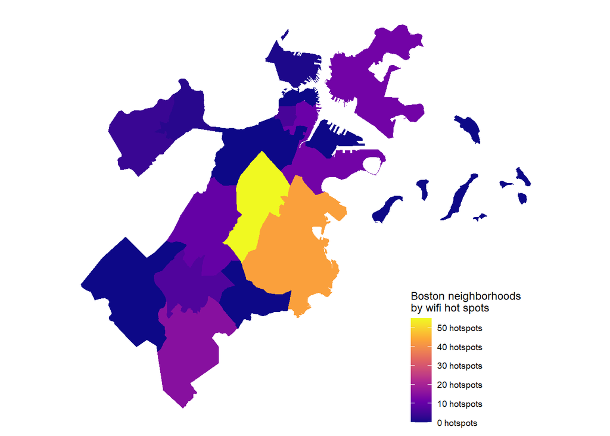

```r
nbhoods <- nbhoods %>%
  mutate(num_wifi = lengths(st_covers(nbhoods, wifi)))

ggplot(nbhoods) +
  geom_sf(color = NA,
          aes(fill = num_wifi)) +
  scale_fill_viridis_c(option = "C", name = "Boston neighborhoods\nby wifi hot spots", breaks = breaks <- seq(0, 50, by = 10),
                       labels = paste(prettyNum(breaks), "hotspots")) +
theme_map() +
  theme(legend.position = c(.7, 0)) +
  theme(legend.background = element_rect(fill = alpha("white", 0.5)))
```

## 4) The number and proportion of D polygons containing B points.

How many Boston neighborhoods (D) contain community centers (B)?

```r
nbhoods <- nbhoods %>%
  mutate(num_commcenter = lengths(st_covers(nbhoods, commcenter))) %>%
  mutate(has_commcenter = num_commcenter > 0)
```

```r
n_commcenter_nbhoods <- sum(nbhoods$has_commcenter)

n_commcenter_nbhoods
```

```
## [1] 15
```

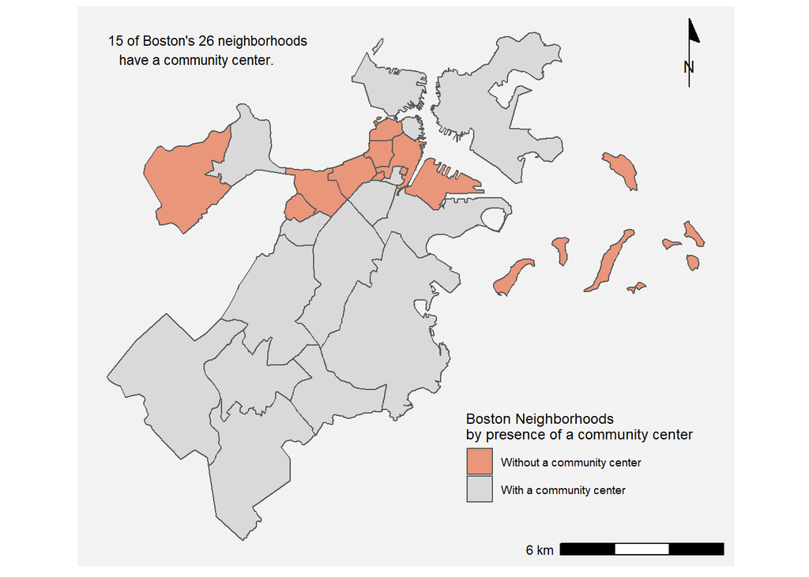

```r
ggplot(nbhoods) +
  geom_sf(fill = NA, color = NA) +
  geom_sf(data = nbhoods,
          aes(fill = has_commcenter)) +
  scale_fill_manual(values = c("darksalmon", "gray85"),
          name = "Boston Neighborhoods\nby presence of a community center",
          labels = c("Without a community center",
                     "With a community center")) +
  annotation_scale(location = "br") +
  annotation_north_arrow(location = "tr",
                         style = north_arrow_minimal()) +
  annotate(geom = "text", x = left_side,
           y = top_side - 1000,
           label = paste(n_commcenter_nbhoods ,
                         "of Boston's",
                         length(nbhoods$Name),
                         "neighborhoods\nhave a community center."),
           hjust = .25, vjust = -1.5, size = 3) +
  theme_map() +
  theme(legend.position = c(.58, .1)) +
  theme(panel.background = element_rect(fill = "gray95", color = NA),
        legend.background = element_rect(fill = alpha("white", 0.1)))
```

```r
nbhoods <- nbhoods %>%
  mutate(num_commcenter = lengths(st_covers(nbhoods, commcenter)))
```

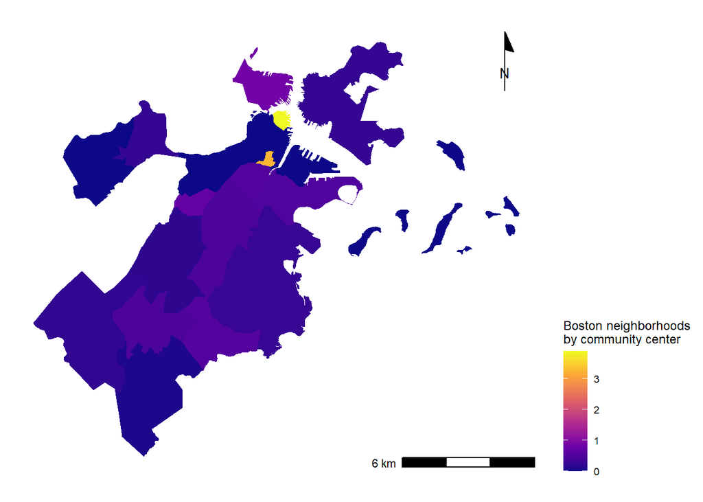

```r
nbhoods <- nbhoods %>%
  mutate(area = set_units(st_area(nbhoods), km^2)) %>%
  mutate(commcenter_dens = as.numeric(num_commcenter / area))

ggplot(nbhoods) +
  geom_sf(color = NA,
          aes(fill = commcenter_dens)) +
    scale_fill_viridis_c(option = "C", name = "Boston neighborhoods\nby community center") +
  annotation_scale(location = "br") +
  annotation_north_arrow(location = "tr",
                         style = north_arrow_minimal()) +
theme_map() +
  theme(legend.position = "right",
    legend.background = element_rect(fill = alpha("white", 0.5)))
```

## 5) The average (Euclidean) distance between B points and their nearest respective E points.

The average distance between a community center (B) and it’s respective public school (E) is 204 meters.

```r
commcenter <- commcenter %>%
  mutate(school_dist = st_nn(commcenter, school,
                           returnDist = TRUE)$dist) %>%
  mutate(school_dist = as.numeric(school_dist))
```

```r
avg_school_dist <- mean(commcenter$school_dist)

avg_school_dist
```

```
## [1] 203.6591
```

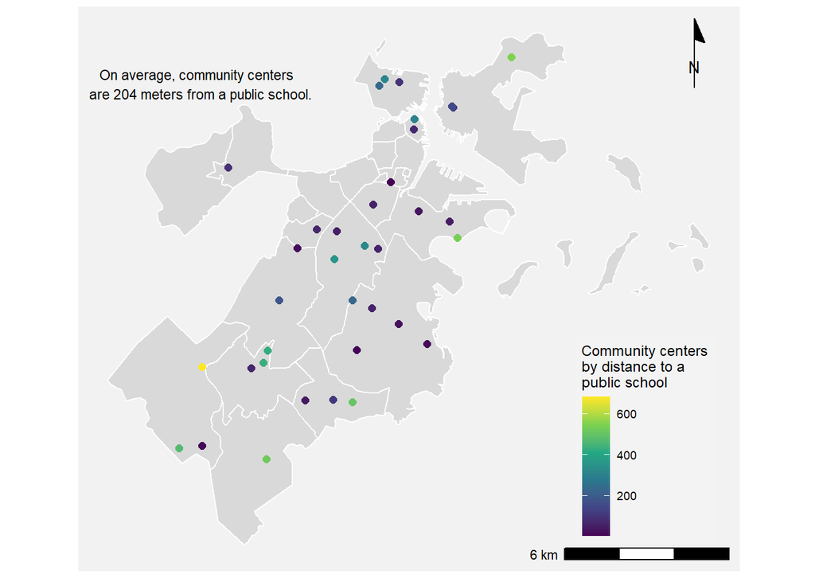

```r
ggplot(nbhoods) +
  geom_sf(fill = "gray85", color = "white") +
  geom_sf(data = commcenter, size = 2,
          aes(color = school_dist)) +
  scale_color_viridis_c(name =
                          "Community centers\nby distance to a\npublic school") +
  annotation_scale(location = "br") +
  annotation_north_arrow(location = "tr",
                         style = north_arrow_minimal()) +
  annotate(geom = "text", x = left_side + 300,
           y = top_side - 550,
           label = paste("On average, community centers\nare ",
                         prettyNum(avg_school_dist, digits = 3),
                         " meters from a public school.",
                         sep = ""),
           hjust = .35, vjust = 0, size = 3) +
  theme_map() +
  theme(legend.position = c(.75, .05)) +
  theme(panel.background = element_rect(fill = "gray95", color = NA),
        legend.background = element_rect(fill = alpha("white", .1)))
```

## 6) The number and proportion of C polygons that overlap with D polygons.

```r
nbhoods <- nbhoods %>%
  mutate(num_openspace = lengths(st_overlaps(nbhoods, openspace))) %>%
  mutate(has_openspace = num_openspace > 0)
```

```r
n_openspace_nbhoods <- sum(nbhoods$has_openspace)

n_openspace_nbhoods
```

```
## [1] 25
```

25 out of 26 of Boston’s neighborhoods contain or overlap with open space. This is a boring figure.

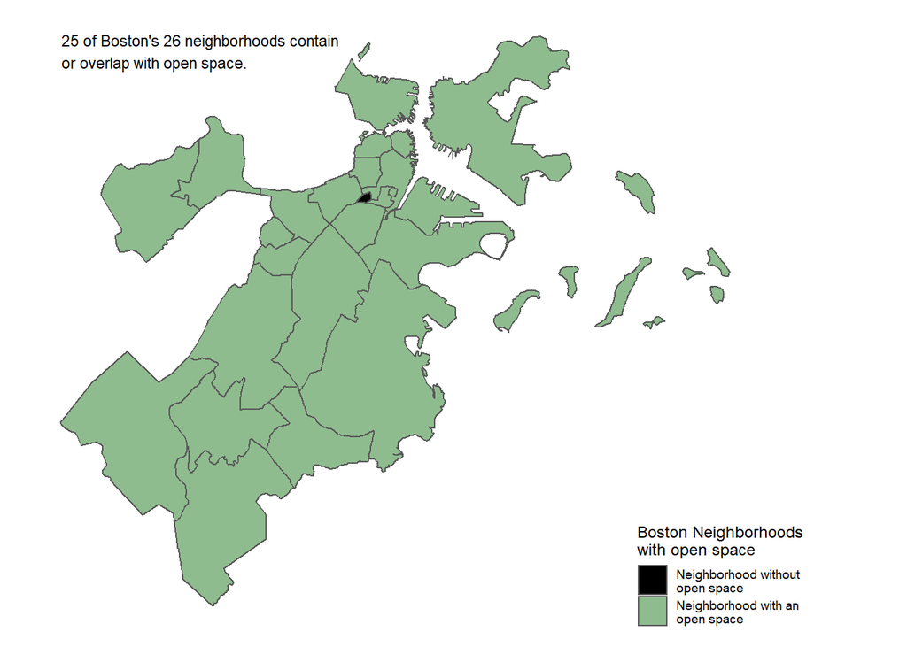

```r
left_side  <- st_bbox(openspace)$xmin
top_side <- st_bbox(openspace)$ymax

ggplot(openspace) +
  geom_sf(fill = NA, color = "white") +
  geom_sf(data = nbhoods,
          aes(fill = has_openspace)) +
  scale_fill_manual(values = c("black", "darkseagreen"),
          name = "Boston Neighborhoods\nwith open space",
          labels = c("Neighborhood without\nopen space",
                     "Neighborhood with an\nopen space")) +
  annotate(geom = "text", x = left_side,
           y = top_side - 1000,
           label = paste(n_openspace_nbhoods ,
                         "of Boston's",
                         length(nbhoods$Name),
                         "neighborhoods contain\nor overlap with",
                         "open space."),
           hjust = 0, vjust = 0, size = 3) +
  theme_map() +
  theme(legend.position = c(.7, 0)) +
  theme(panel.background = element_rect(fill = "white", color = NA),
        legend.background = element_rect(fill = alpha("white", 0.5)))
```